# Aula 05

Pacotes utilizados neste RMD.

```r
library("rmdformats")
library("readxl")
```

# Exercício 1

Um grupo de pacientes com problemas cardíacos foi avaliado para um estudo sobre eficiência de um medicamento. Os níveis de colesterol (lipoproteínas de alta densidade, HDL) foram medidos e estão descritos a seguir.

```r
niveis <- c(125.6, 124.2, 127.3, 155, 143.3, 147.9, 119.9, 99.7, 133.9, 110.9, 126.3, 149.9, 130.7, 146.1, 134.3, 139.4, 153.7, 151, 146.5, 129.5, 131.3, 136.5, 126.7, 145.1, 147.9, 132.2, 145.5, 145.2, 148.5, 165.2)
```

## a) Verifique a suposição de normalidade da variável de estudo.

**Resolução:** Primeiramente, é interessante plotarmos o gráfico de sua distribuição para termos um primeiro olhar se a amostra se aproxima de uma distribuição normal ou não. Podemos criar um histograma bem básico apenas para fazermos essa visualização inicial.

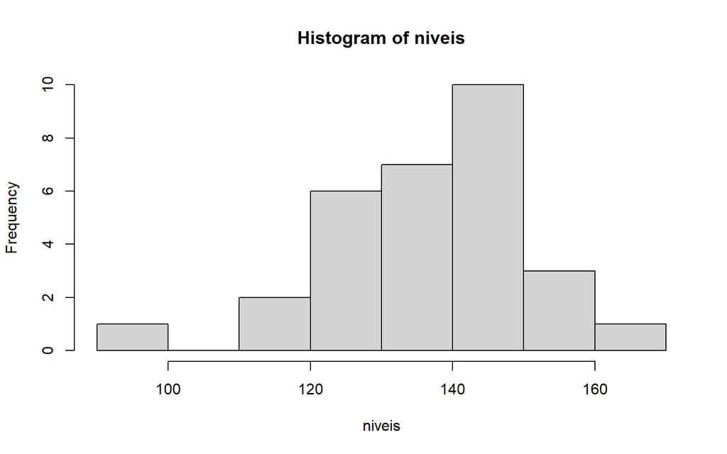

```r
hist(niveis)
```

Em seguida, podemos utilizar o teste de hipóteses de Shapiro-Wilk para testar a normalidade da nossa amostra. Este teste toma como hipótese inicial de que os dados da amostra seguem uma distribuição normal. Consideraremos o nível $\alpha = 0.05$.

```r
shapiro.test(niveis)
```

```
##
##  Shapiro-Wilk normality test
##
## data:  niveis
## W = 0.9639, p-value = 0.3881
```

## b) O nível médio de colesterol HDL destes pacientes é maior do que 130mg/dl? Utilize um nível de significância de 0,05.

Queremos saber se a média populacional está acima de 130mg/dl, então aplicamos um teste unilateral da seguinte forma:

```r
wilcox.test(niveis,
alternative="greater",mu=130)
```

```
##
##  Wilcoxon signed rank test with continuity correction
##
## data:  niveis
## V = 358, p-value = 0.005069
## alternative hypothesis: true location is greater than 130
```

# Exercício 2

A secretaria municipal afirmou que no máximo 15% das residências possuem ciradouros de dengue. Um levantamento foi realizado e foram encontrados criadouros de dengue em 62 de 586 residências visitadas. Com nível de significância de 0.05, verifique a veracidade da afirmação.

**Resolução:** Observemos inicialmente a porcentagem de dengue encontrada no levantamento em questão.

```r
cat(62/586*100,"%")
```

```
## 10.5802 %
```

Assim, esse único levantamento apenas reforça a afirmação dada anteriormente, desde que o levantamento tenha sido feito de forma apropriada neste experimento. Mas vale ressaltar que apenas um exemplo afirmativo não comprova a veracidade da afirmação dita pela secretaria.

Por isso, iremos aplicar um teste de hipóteses chamado Teste Binomial para testar sobre a verdadeira probabilidade de ocorrer dengue numa certa residência deste município. Tomaremos a afirmação da secretaria como hipótese nula.

```r
binom.test(x = 62, n = 586, p = 0.15, alternative = "less")
```

```
##
##  Exact binomial test
##
## data:  62 and 586
## number of successes = 62, number of trials = 586, p-value = 0.001112
## alternative hypothesis: true probability of success is less than 0.15
## 95 percent confidence interval:
##  0.0000000 0.1290574
## sample estimates:
## probability of success
##               0.105802
```